# Task-5 Chromosome-Level Effects of MSL Knockdown in Drosophila S2 RNA-seq Data

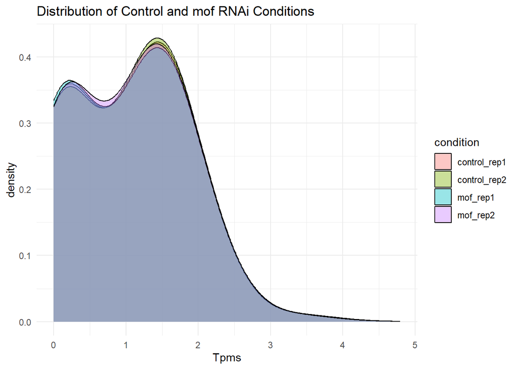

```r
ggplot(data = tpms_longer2, mapping = aes(x=log10(tpms+1), group = condition, fill = condition))+
  geom_density(bw = 0.4, alpha = 0.4)+
  labs(title = "Distribution of Control and mof RNAi Conditions", x = "Tpms", y ="density")+
  theme_minimal()
```

```r
dds <- DESeqDataSetFromMatrix(countData = counts, colData = samples, design = ~condition)
dds <- DESeq(dds)
results1 <- results(dds)
results1
```

```
## log2 fold change (MLE): condition msl2 vs control
## Wald test p-value: condition msl2 vs control
## DataFrame with 10990 rows and 6 columns
##               baseMean log2FoldChange     lfcSE       stat    pvalue      padj
##              <numeric>      <numeric> <numeric>  <numeric> <numeric> <numeric>
## FBgn0025836   8.657357      -0.584963  1.001003 -0.5843770 0.5589667        NA
## FBgn0284435   0.792690      -0.302647  3.056220 -0.0990267 0.9211171        NA
## FBgn0025835   0.855991      -0.207131  3.475716 -0.0595937 0.9524792        NA
## FBgn0040373  31.015215       0.922820  0.529060  1.7442650 0.0811129        NA
## FBgn0040372 190.965893      -0.320479  0.234984 -1.3638345 0.1726197  0.655026
## ...                ...            ...       ...        ...       ...       ...
## FBgn0039886  271.09255     -0.1760214  0.223951 -0.7859811 0.4318786 0.8769518
## FBgn0039887    1.15871     -0.6826957  2.653269 -0.2573036 0.7969444        NA
## FBgn0040206  273.40143      0.0378430  0.194499  0.1945665 0.8457323 0.9873550
## FBgn0002780 1240.18683      0.4143661  0.127013  3.2623832 0.0011048 0.0339377
## FBgn0002645 1239.69426     -0.0115133  0.138156 -0.0833352 0.9335850 0.9938111
```

```r
results2 <- results(dds, contrast = c("condition","mof", "control"))
results2
```

```
## log2 fold change (MLE): condition mof vs control
## Wald test p-value: condition mof vs control
## DataFrame with 10990 rows and 6 columns
##               baseMean log2FoldChange     lfcSE      stat      pvalue
##              <numeric>      <numeric> <numeric> <numeric>   <numeric>
## FBgn0025836   8.657357       1.121421  0.929768  1.206130    0.227768
## FBgn0284435   0.792690      -1.072038  3.202091 -0.334793    0.737781
## FBgn0025835   0.855991       1.674048  3.272543  0.511543    0.608971
## FBgn0040373  31.015215       0.771130  0.534909  1.441611    0.149412
## FBgn0040372 190.965893      -0.206109  0.235452 -0.875376    0.381369
## ...                ...            ...       ...       ...         ...
## FBgn0039886  271.09255      0.0742468  0.223486  0.332221 7.39723e-01
## FBgn0039887    1.15871     -0.6751795  2.675380 -0.252368 8.00757e-01
## FBgn0040206  273.40143      0.0529028  0.195509  0.270590 7.86707e-01
## FBgn0002780 1240.18683      0.5627756  0.127058  4.429268 9.45536e-06
## FBgn0002645 1239.69426      0.0539341  0.138371  0.389780 6.96699e-01
##                   padj
##              <numeric>
## FBgn0025836         NA
## FBgn0284435         NA
## FBgn0025835         NA
## FBgn0040373         NA
## FBgn0040372   0.777799
## ...                ...
## FBgn0039886 0.94533980
## FBgn0039887         NA
## FBgn0040206 0.96067915
## FBgn0002780 0.00219379
## FBgn0002645 0.93389602
```

```r
results1 <- as.data.frame(results1)
results1 <- tibble::rownames_to_column(results1, var = "flybase_gene_id")
results2 <- as.data.frame(results2)
results2 <- tibble::rownames_to_column(results2, var = "flybase_gene_id")

genes_com <- rowData(se, use.names = TRUE)
genes_com <- as.data.frame(genes_com)
genes_com <- tibble::rownames_to_column(genes_com, var = "flybase_gene_id")

base::nrow(genes_com)
```

```
## [1] 10990
```

```r
base::nrow(results1)
```

```
## [1] 10990
```

```r
base::names(genes_com)
```

```
## [1] "flybase_gene_id" "gene_name"       "chromosome"      "start"
## [5] "end"             "gene_length"
```

```r
base::names(results1)
```

```
## [1] "flybase_gene_id" "baseMean"        "log2FoldChange"  "lfcSE"
## [5] "stat"            "pvalue"          "padj"
```

```r
base::length(base::unique(genes_com$flybase_gene_id))
```

```
## [1] 10990
```

```r
base::length(base::unique(results1$flybase_gene_id))
```

```
## [1] 10990
```

```r
results1_com <- dplyr::left_join(x= genes_com, y= results1, by= "flybase_gene_id" )

base::nrow(genes_com)
```

```
## [1] 10990
```

```r
base::nrow(results2)
```

```
## [1] 10990
```

```r
base::names(genes_com)
```

```
## [1] "flybase_gene_id" "gene_name"       "chromosome"      "start"
## [5] "end"             "gene_length"
```

```r
base::names(results2)
```

```
## [1] "flybase_gene_id" "baseMean"        "log2FoldChange"  "lfcSE"
## [5] "stat"            "pvalue"          "padj"
```

```r
base::length(base::unique(genes_com$flybase_gene_id))
```

```
## [1] 10990
```

```r
base::length(base::unique(results2$flybase_gene_id))
```

```
## [1] 10990
```

```r
results2_com <- dplyr::left_join(x= genes_com, y= results2, by= "flybase_gene_id" )

sum(is.na(results1_com$log2FoldChange))
```

```
## [1] 73
```

```r
sum(is.na(results1_com$pvalue))
```

```
## [1] 73
```

```r
sum(is.na(results1_com$lfcSE))
```

```
## [1] 73
```

```r
sum(is.na(results1_com$stat))
```

```
## [1] 73
```

```r
sum(is.na(results1_com$padj))
```

```
## [1] 6843
```

```r
sum(is.na(results2_com$log2FoldChange))
```

```
## [1] 73
```

```r
sum(is.na(results2_com$pvalue))
```

```
## [1] 73
```

```r
sum(is.na(results2_com$lfcSE))
```

```
## [1] 73
```

```r
sum(is.na(results2_com$stat))
```

```
## [1] 73
```

```r
sum(is.na(results2_com$padj))
```

```
## [1] 7478
```

```r
results1_com_cle <- filter(results1_com, !is.na(results1_com$log2FoldChange))
results2_com_cle <- filter(results2_com, !is.na(results2_com$log2FoldChange))

table(results1_com_cle$chromosome)
```

```
##
##   2L   2R   3L   3R    X
## 2068 2233 2092 2698 1826
```

```r
table(results2_com_cle$chromosome)
```

```
##
##   2L   2R   3L   3R    X
## 2068 2233 2092 2698 1826
```

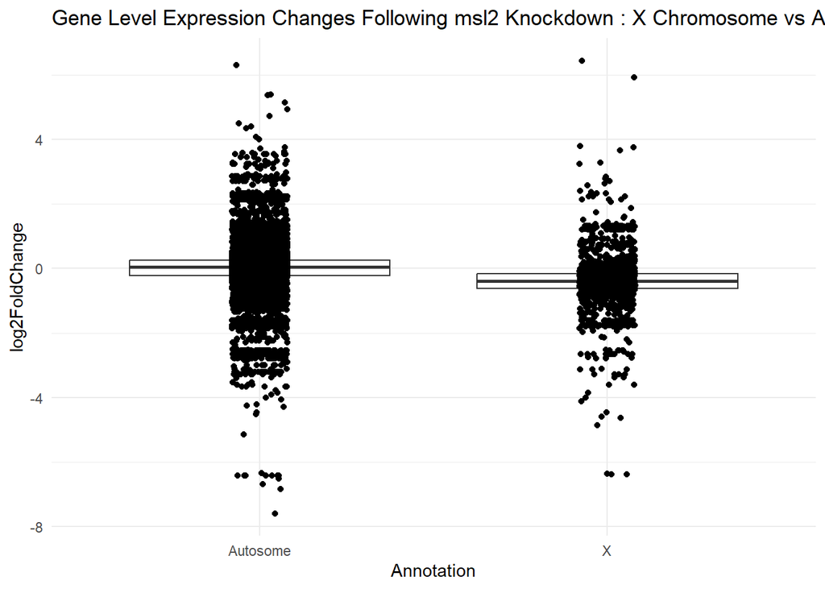

```r
results1_com_cle <- results1_com_cle %>% mutate(Annotation = if_else(chromosome == "X", "X", "Autosome"))
results2_com_cle <- results2_com_cle %>% mutate(Annotation = if_else(chromosome == "X", "X", "Autosome"))

ggplot(data = results1_com_cle, mapping = aes(x = Annotation, y= log2FoldChange))+
  geom_boxplot(outlier.shape = NA)+
  geom_jitter(width = 0.08,
              height = 0)+
  labs(title = "Gene Level Expression Changes Following msl2 Knockdown : X Chromosome vs Autosome", x = "Annotation", y= "log2FoldChange")+
  theme_minimal()
```

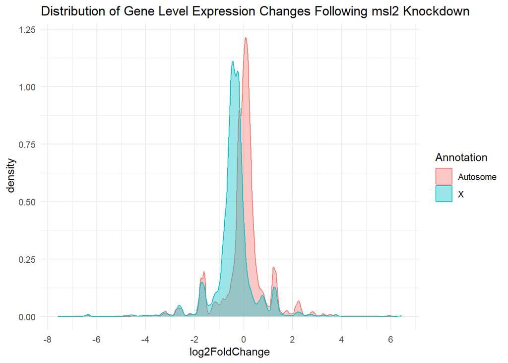

```r
ggplot(data = results1_com_cle, mapping = aes(x = log2FoldChange, colour = Annotation, fill = Annotation))+
  geom_density(alpha = 0.4)+
  scale_y_continuous(breaks = seq(0, 1.25, by = 0.25))+
  scale_x_continuous(breaks = seq(-8, 8, by =2))+
  labs(title = "Distribution of Gene Level Expression Changes Following msl2 Knockdown", x = "log2FoldChange", y =" density")+
  theme_minimal()
```

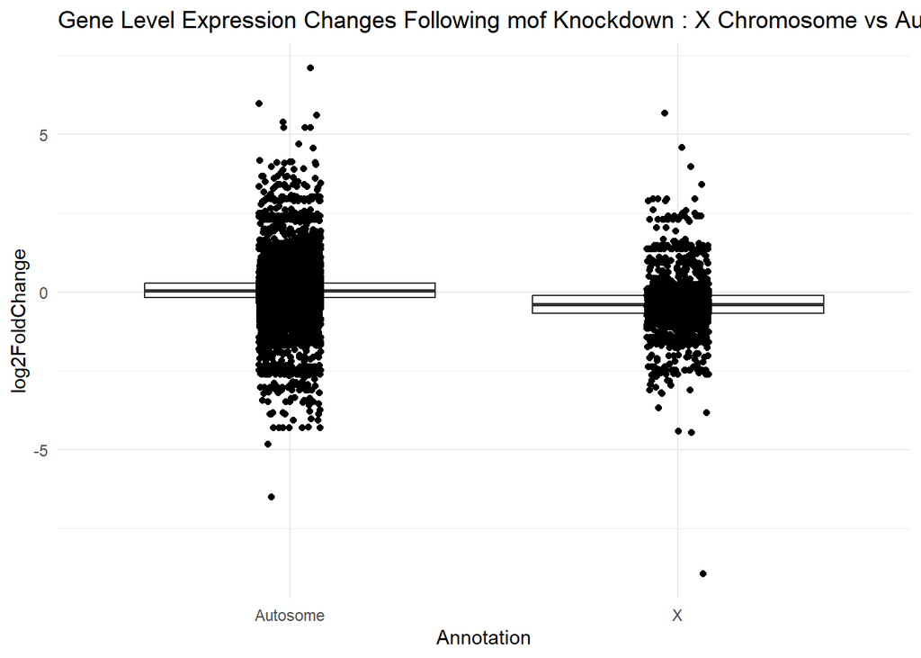

```r
ggplot(data = results2_com_cle, mapping = aes(x = Annotation, y= log2FoldChange))+
  geom_boxplot(outlier.shape = NA)+
  geom_jitter(width = 0.08,
              height = 0)+
  labs(title = "Gene Level Expression Changes Following mof Knockdown : X Chromosome vs Autosome", x = "Annotation", y= "log2FoldChange")+
  theme_minimal()
```

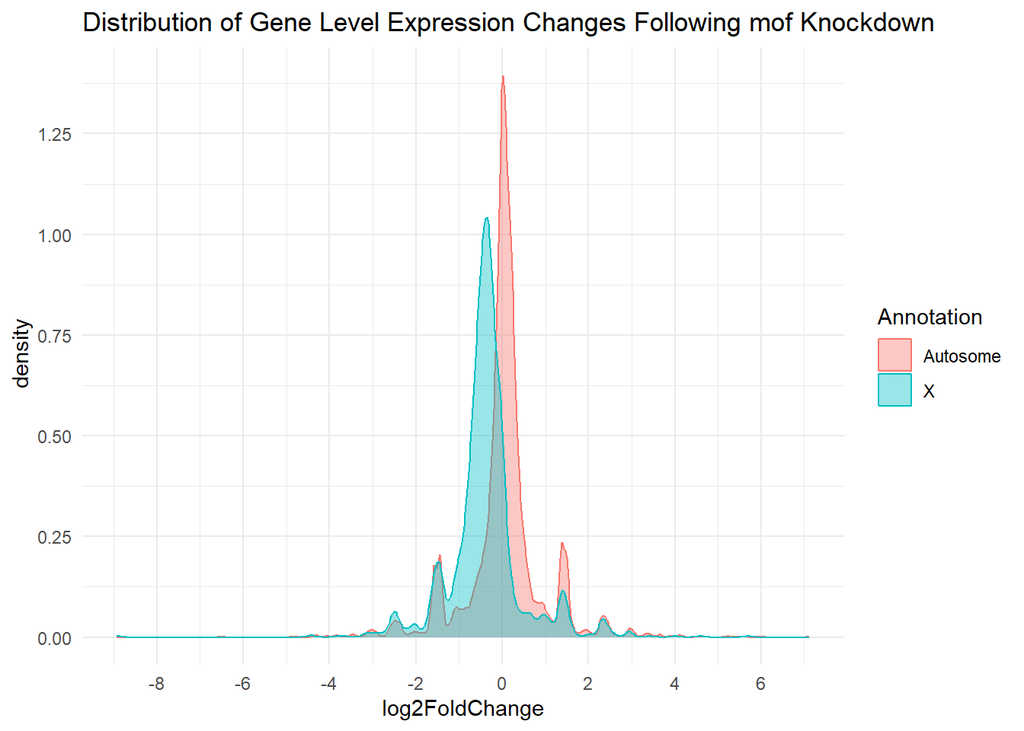

```r
ggplot(data = results2_com_cle, mapping = aes(x = log2FoldChange, colour = Annotation, fill = Annotation))+
  geom_density(alpha = 0.4)+
  scale_y_continuous(breaks = seq(0, 1.25, by = 0.25))+
  scale_x_continuous(breaks = seq(-8, 8, by =2))+
  labs(title = "Distribution of Gene Level Expression Changes Following mof Knockdown", x = "log2FoldChange", y =" density")+
  theme_minimal()
```

```r
aggregate(log2FoldChange ~ Annotation, data = results1_com_cle, FUN = mean)
```

```
##   Annotation log2FoldChange
## 1   Autosome   -0.002162467
## 2          X   -0.399133920
```

```r
aggregate(log2FoldChange ~ Annotation, data = results2_com_cle, FUN = mean)
```

```
##   Annotation log2FoldChange
## 1   Autosome     0.03692824
## 2          X    -0.38410726
```

```r
aggregate(log2FoldChange ~ Annotation, data = results1_com_cle, FUN = sd)
```

```
##   Annotation log2FoldChange
## 1   Autosome      0.9165174
## 2          X      0.8563156
```

```r
aggregate(log2FoldChange ~ Annotation, data = results2_com_cle, FUN = sd)
```

```
##   Annotation log2FoldChange
## 1   Autosome       0.899422
## 2          X       0.873471
```

```r
aggregate(log2FoldChange ~ Annotation, data = results1_com_cle, FUN = median)
```

```
##   Annotation log2FoldChange
## 1   Autosome     0.03980791
## 2          X    -0.39352692
```

```r
aggregate(log2FoldChange ~ Annotation, data = results2_com_cle, FUN = median)
```

```
##   Annotation log2FoldChange
## 1   Autosome     0.04705051
## 2          X    -0.38776490
```

## Explanations

RNA-seq measures presence , identity and quantity of RNA molecules that are in the biological sample.It is widely used for gene expression analysis, including detection of mutations, alternative splicing, and post-transcriptional modifications. The result measurements can be represented in a count matrix. A count matrix is a table of non negative integers where each row is a gene and each column is a sample that is in bulk RNA-seq or a single cell. Each entry demonstrates the number of sequencing reads or unique molecules assigned to that gene in that sample or cell. Before comparing these values across samples, normalization needs to be considered. RNA-seq normalization is essential for accurate RNA-seq data analysis. Various factors affect transcript quantification in RNA-seq data such as sequencing depth, transcript length, sample and batch variability. Normalization methods exist to minimize these variables and ensure reliable transcriptomic data. TPM (Transcripts per million) and RPKM(reads per kilobase of transcript per million reads mapped) are examples of normalized expression values. both of them account for gene lenght and sequencing depth. They describe the relative expression level of a gene rather than the exact number of RNA molecules.[17-19]

## Resources

1. https://www.geeksforgeeks.org/r-language/how-to-import-tsv-files-into-r/#google_vignette
2. https://www.r-bloggers.com/2021/06/compare-data-frames-in-r-quick-guide/
3. https://www.r-bloggers.com/2021/07/countif-function-in-r/
4. https://www.youtube.com/watch?v=LtYoJP0L0rk
5. https://www.rdocumentation.org/packages/SummarizedExperiment/versions/1.2.3/topics/SummarizedExperiment-class
6. https://bioconductor.org/packages/release/bioc/html/SummarizedExperiment.html
7. https://www.reddit.com/r/Rlanguage/comments/z71jk8/converting_a_dataframe_from_wide_to_long_format/
8. https://www.youtube.com/watch?v=UR-4vBEN3Fw
9. https://stackoverflow.com/questions/29511215/how-can-i-convert-row-names-into-the-first-column
10. https://www.youtube.com/watch?v=CftlEnJz2ws
11. https://www.youtube.com/watch?v=6mw5OYLji9c
12. https://www.youtube.com/watch?v=xerW2TvZHbQ
13. https://www.youtube.com/watch?v=OzNzO8qwwp0&t=341s
14. https://www.researchgate.net/post/How-to-interpret-results-of-DESeq2-with-more-than-two-experimental-groups
15. https://bioconductor.org/packages/devel/bioc/vignettes/DESeq2/inst/doc/DESeq2.html#differential-expression-analysis
16. https://notchbio.app/blog/log2-fold-change-cutoffs-rna-seq/
17. https://divingintogeneticsandgenomics.com/learn/glossary/count-matrix/
18. https://www.neb.com/de-de/tools-and-resources/usage-guidelines/getting-started-with-rna-seq?srsltid=AYCX9vJCSyE_LLq4tQYS8VE2w25a-DQKLwasOoyEDHmtOfBK3ltTC2Jl
19. https://bigomics.ch/blog/why-how-normalize-rna-seq-data/